# Kira Plastinina

2022-07-23

## *Problem Definition*

*Specifying the Data Analytic Question*

> As a Data Science Consultant, I have been employed by Kira Plastinina brand’s Sales and Marketing team. They would like to understand their customer’s behavior from data that they have collected over the past year. More specifically, they would like to learn the characteristics of customer groups.

*Defining the Metric for Success*

> - Perform clustering stating insights drawn from your analysis and visualizations.
> - Upon implementation, provide comparisons between K-Means clustering and Hierarchical clustering highlighting the strengths and limitations of each approach in the context of your analysis.

*Understanding the context*

> There have been opened over 120 Kira Plastinina signature stores in different parts of the world: Russia, Ukraine, Italy, Great Britain, USA, China, Philippines, etc.. The stores present the collections of apparel, shoes, perfumes and accessories. In Russia, there have been opened 34 Kira Plastinina stores in Moscow, plus, the brand’s network embraces 100 cities and towns of Russia.

*Recording the Experimental Design*

- Problem Definition
- Data Sourcing
- Check the Data
- Perform Data Cleaning
- Perform Exploratory Data Analysis (Univariate, Bivariate & Multivariate)
- Implement the Solution
- Challenge the Solution
- Follow up Questions

*Data Relevance*

> The dataset consists of 10 numerical and 8 categorical attributes. The ‘Revenue’ attribute can be used as the class label.

> “Administrative”, “Administrative Duration”, “Informational”, “Informational Duration”, “Product Related” and “Product Related Duration” represents the number of different types of pages visited by the visitor in that session and total time spent in each of these page categories. The values of these features are derived from the URL information of the pages visited by the user and updated in real-time when a user takes an action, e.g. moving from one page to another.

> The “Bounce Rate”, “Exit Rate” and “Page Value” features represent the metrics measured by “Google Analytics” for each page in the e-commerce site.

> The value of the “Bounce Rate” feature for a web page refers to the percentage of visitors who enter the site from that page and then leave (“bounce”) without triggering any other requests to the analytics server during that session.

> The value of the “Exit Rate” feature for a specific web page is calculated as for all pageviews to the page, the percentage that was the last in the session.

> The “Page Value” feature represents the average value for a web page that a user visited before completing an e-commerce transaction.

> The “Special Day” feature indicates the closeness of the site visiting time to a specific special day (e.g. Mother’s Day, Valentine’s Day) in which the sessions are more likely to be finalized with the transaction. The value of this attribute is determined by considering the dynamics of e-commerce such as the duration between the order date and delivery date. For example, for Valentina’s day, this value takes a nonzero value between February 2 and February 12, zero before and after this date unless it is close to another special day, and its maximum value of 1 on February 8.

> The dataset also includes the operating system, browser, region, traffic type, visitor type as returning or new visitor, a Boolean value indicating whether the date of the visit is weekend, and month of the year.

## *Data Sourcing*

```r
#Installing packages
#
install.packages('tidyverse', repos = "http://cran.us.r-project.org")
```

```r
install.packages('ggplot2', repos = "http://cran.us.r-project.org")
install.packages('caret', repos = "http://cran.us.r-project.org")
install.packages('caretEnsemble', repos = "http://cran.us.r-project.org")
install.packages('Amelia', repos = "http://cran.us.r-project.org")
install.packages('mice', repos = "http://cran.us.r-project.org")
install.packages('GGally', repos = "http://cran.us.r-project.org")
install.packages('rpart', repos = "http://cran.us.r-project.org")
install.packages("readr", repos = "http://cran.us.r-project.org")
install.packages("dplyr", repos = "http://cran.us.r-project.org")
install.packages("dendextend", repos = "http://cran.us.r-project.org")
install.packages("factoextra", repos = "http://cran.us.r-project.org")
install.packages("cluster", repos = "http://cran.us.r-project.org")
#Install respective libraries
library(tidyverse)
library(ggplot2)
library(caret)
library(caretEnsemble)
library(Amelia)
library(mice)
library(GGally)
library(rpart)
library(readr)
library(dplyr)
library(dendextend)
library(factoextra)
library(cluster)
```

```r
#Read the dataset
shoppers <- read_csv("C://Users//Lenovo//Downloads//DB_prep//online_shoppers_intention.csv")
```

## *Check the Data*

```r
#Find the column names
colnames(shoppers)
```

```
##  [1] "Administrative"          "Administrative_Duration"
##  [3] "Informational"           "Informational_Duration"
##  [5] "ProductRelated"          "ProductRelated_Duration"
##  [7] "BounceRates"             "ExitRates"
##  [9] "PageValues"              "SpecialDay"
## [11] "Month"                   "OperatingSystems"
## [13] "Browser"                 "Region"
## [15] "TrafficType"             "VisitorType"
## [17] "Weekend"                 "Revenue"
```

```r
#Checking the head and tail of the data

head(shoppers)
```

```
## # A tibble: 6 × 18
##   Administrative Administrative_D… Informational Informational_D… ProductRelated
##            <dbl>             <dbl>         <dbl>            <dbl>          <dbl>
## 1              0                 0             0                0              1
## 2              0                 0             0                0              2
## 3              0                -1             0               -1              1
## 4              0                 0             0                0              2
## 5              0                 0             0                0             10
## 6              0                 0             0                0             19
## # … with 13 more variables: ProductRelated_Duration <dbl>, BounceRates <dbl>,
## #   ExitRates <dbl>, PageValues <dbl>, SpecialDay <dbl>, Month <chr>,
## #   OperatingSystems <dbl>, Browser <dbl>, Region <dbl>, TrafficType <dbl>,
## #   VisitorType <chr>, Weekend <lgl>, Revenue <lgl>
```

```r
tail(shoppers)
```

```
## # A tibble: 6 × 18
##   Administrative Administrative_D… Informational Informational_D… ProductRelated
##            <dbl>             <dbl>         <dbl>            <dbl>          <dbl>
## 1              0                 0             1                0             16
## 2              3               145             0                0             53
## 3              0                 0             0                0              5
## 4              0                 0             0                0              6
## 5              4                75             0                0             15
## 6              0                 0             0                0              3
## # … with 13 more variables: ProductRelated_Duration <dbl>, BounceRates <dbl>,
## #   ExitRates <dbl>, PageValues <dbl>, SpecialDay <dbl>, Month <chr>,
## #   OperatingSystems <dbl>, Browser <dbl>, Region <dbl>, TrafficType <dbl>,
## #   VisitorType <chr>, Weekend <lgl>, Revenue <lgl>
```

```r
#The rows and columns in the data
cat("The dataset has ", dim(shoppers)[1], "rows and ", dim(shoppers)[2], " columns")
```

```
## The dataset has  12330 rows and  18  columns
```

```r
# Seeing the structure of the dataset
str(shoppers)
```

```
## spec_tbl_df [12,330 × 18] (S3: spec_tbl_df/tbl_df/tbl/data.frame)
##  $ Administrative         : num [1:12330] 0 0 0 0 0 0 0 1 0 0 ...
##  $ Administrative_Duration: num [1:12330] 0 0 -1 0 0 0 -1 -1 0 0 ...
##  $ Informational          : num [1:12330] 0 0 0 0 0 0 0 0 0 0 ...
##  $ Informational_Duration : num [1:12330] 0 0 -1 0 0 0 -1 -1 0 0 ...
##  $ ProductRelated         : num [1:12330] 1 2 1 2 10 19 1 1 2 3 ...
##  $ ProductRelated_Duration: num [1:12330] 0 64 -1 2.67 627.5 ...
##  $ BounceRates            : num [1:12330] 0.2 0 0.2 0.05 0.02 ...
##  $ ExitRates              : num [1:12330] 0.2 0.1 0.2 0.14 0.05 ...
##  $ PageValues             : num [1:12330] 0 0 0 0 0 0 0 0 0 0 ...
##  $ SpecialDay             : num [1:12330] 0 0 0 0 0 0 0.4 0 0.8 0.4 ...
##  $ Month                  : chr [1:12330] "Feb" "Feb" "Feb" "Feb" ...
##  $ OperatingSystems       : num [1:12330] 1 2 4 3 3 2 2 1 2 2 ...
##  $ Browser                : num [1:12330] 1 2 1 2 3 2 4 2 2 4 ...
##  $ Region                 : num [1:12330] 1 1 9 2 1 1 3 1 2 1 ...
##  $ TrafficType            : num [1:12330] 1 2 3 4 4 3 3 5 3 2 ...
##  $ VisitorType            : chr [1:12330] "Returning_Visitor" "Returning_Visitor" "Returning_Visitor" "Returning_Visitor" ...
##  $ Weekend                : logi [1:12330] FALSE FALSE FALSE FALSE TRUE FALSE ...
##  $ Revenue                : logi [1:12330] FALSE FALSE FALSE FALSE FALSE FALSE ...
##  - attr(*, "spec")=
##   .. cols(
##   ..   Administrative = col_double(),
##   ..   Administrative_Duration = col_double(),
##   ..   Informational = col_double(),
##   ..   Informational_Duration = col_double(),
##   ..   ProductRelated = col_double(),
##   ..   ProductRelated_Duration = col_double(),
##   ..   BounceRates = col_double(),
##   ..   ExitRates = col_double(),
##   ..   PageValues = col_double(),
##   ..   SpecialDay = col_double(),
##   ..   Month = col_character(),
##   ..   OperatingSystems = col_double(),
##   ..   Browser = col_double(),
##   ..   Region = col_double(),
##   ..   TrafficType = col_double(),
##   ..   VisitorType = col_character(),
##   ..   Weekend = col_logical(),
##   ..   Revenue = col_logical()
##   .. )
##  - attr(*, "problems")=<externalptr>
```

```r
#checking the datatypes on the columns
sapply(shoppers, class)
```

```
##          Administrative Administrative_Duration           Informational
##               "numeric"               "numeric"               "numeric"
##  Informational_Duration          ProductRelated ProductRelated_Duration
##               "numeric"               "numeric"               "numeric"
##             BounceRates               ExitRates              PageValues
##               "numeric"               "numeric"               "numeric"
##              SpecialDay                   Month        OperatingSystems
##               "numeric"             "character"               "numeric"
##                 Browser                  Region             TrafficType
##               "numeric"               "numeric"               "numeric"
##             VisitorType                 Weekend                 Revenue
##             "character"               "logical"               "logical"
```

```r
#summary of the dataset
#Basic descriptive statistics and frequencies.

summary(shoppers)
```

```
##  Administrative   Administrative_Duration Informational
##  Min.   : 0.000   Min.   :  -1.00         Min.   : 0.000
##  1st Qu.: 0.000   1st Qu.:   0.00         1st Qu.: 0.000
##  Median : 1.000   Median :   8.00         Median : 0.000
##  Mean   : 2.318   Mean   :  80.91         Mean   : 0.504
##  3rd Qu.: 4.000   3rd Qu.:  93.50         3rd Qu.: 0.000
##  Max.   :27.000   Max.   :3398.75         Max.   :24.000
##  NA's   :14       NA's   :14              NA's   :14
##  Informational_Duration ProductRelated   ProductRelated_Duration
##  Min.   :  -1.00        Min.   :  0.00   Min.   :   -1.0
##  1st Qu.:   0.00        1st Qu.:  7.00   1st Qu.:  185.0
##  Median :   0.00        Median : 18.00   Median :  599.8
##  Mean   :  34.51        Mean   : 31.76   Mean   : 1196.0
##  3rd Qu.:   0.00        3rd Qu.: 38.00   3rd Qu.: 1466.5
##  Max.   :2549.38        Max.   :705.00   Max.   :63973.5
##  NA's   :14             NA's   :14       NA's   :14
##   BounceRates         ExitRates         PageValues        SpecialDay
##  Min.   :0.000000   Min.   :0.00000   Min.   :  0.000   Min.   :0.00000
##  1st Qu.:0.000000   1st Qu.:0.01429   1st Qu.:  0.000   1st Qu.:0.00000
##  Median :0.003119   Median :0.02512   Median :  0.000   Median :0.00000
##  Mean   :0.022152   Mean   :0.04300   Mean   :  5.889   Mean   :0.06143
##  3rd Qu.:0.016684   3rd Qu.:0.05000   3rd Qu.:  0.000   3rd Qu.:0.00000
##  Max.   :0.200000   Max.   :0.20000   Max.   :361.764   Max.   :1.00000
##  NA's   :14         NA's   :14
##     Month           OperatingSystems    Browser           Region
##  Length:12330       Min.   :1.000    Min.   : 1.000   Min.   :1.000
##  Class :character   1st Qu.:2.000    1st Qu.: 2.000   1st Qu.:1.000
##  Mode  :character   Median :2.000    Median : 2.000   Median :3.000
##                     Mean   :2.124    Mean   : 2.357   Mean   :3.147
##                     3rd Qu.:3.000    3rd Qu.: 2.000   3rd Qu.:4.000
##                     Max.   :8.000    Max.   :13.000   Max.   :9.000
##
##   TrafficType    VisitorType         Weekend         Revenue
##  Min.   : 1.00   Length:12330       Mode :logical   Mode :logical
##  1st Qu.: 2.00   Class :character   FALSE:9462      FALSE:10422
##  Median : 2.00   Mode  :character   TRUE :2868      TRUE :1908
##  Mean   : 4.07
##  3rd Qu.: 4.00
##  Max.   :20.00
##
```

```r
# list the levels for the class
levels(shoppers$revenue)
```

[output not shown]

## *Perform Data Cleaning*

```r
names(shoppers)<- tolower(names(shoppers)) # make the column names to lowercase
```

```r
# Checking the number of missing per column/variable
colSums(is.na(shoppers))
```

```
##          administrative administrative_duration           informational
##                      14                      14                      14
##  informational_duration          productrelated productrelated_duration
##                      14                      14                      14
##             bouncerates               exitrates              pagevalues
##                      14                      14                       0
##              specialday                   month        operatingsystems
##                       0                       0                       0
##                 browser                  region             traffictype
##                       0                       0                       0
##             visitortype                 weekend                 revenue
##                       0                       0                       0
```

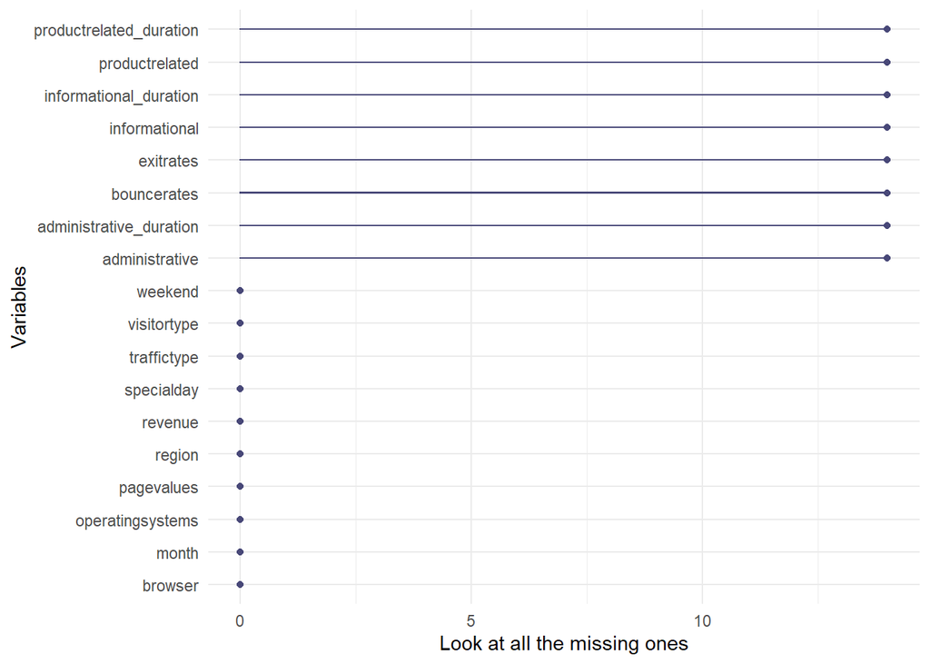

```r
#Using visualizations to see missing data
install.packages("naniar", repos = "http://cran.us.r-project.org")
library(naniar)

gg_miss_var(shoppers) + labs(y = "Look at all the missing ones")
```

## *Dealing with missing values*

```r
#Omit missing values
shoppers <- na.omit(shoppers)
```

```r
# Checking the number of missing per column/variable again
colSums(is.na(shoppers))
```

```
##          administrative administrative_duration           informational
##                       0                       0                       0
##  informational_duration          productrelated productrelated_duration
##                       0                       0                       0
##             bouncerates               exitrates              pagevalues
##                       0                       0                       0
##              specialday                   month        operatingsystems
##                       0                       0                       0
##                 browser                  region             traffictype
##                       0                       0                       0
##             visitortype                 weekend                 revenue
##                       0                       0                       0
```

```r
#Checking for duplicates in data

duplicated_rows <- shoppers[duplicated(shoppers),]
duplicated_rows
```

```
## # A tibble: 117 × 18
##    administrative administrative_… informational informational_d… productrelated
##             <dbl>            <dbl>         <dbl>            <dbl>          <dbl>
##  1              0                0             0                0              1
##  2              0                0             0                0              1
##  3              0                0             0                0              1
##  4              0                0             0                0              1
##  5              0                0             0                0              1
##  6              0                0             0                0              1
##  7              0                0             0                0              1
##  8              0                0             0                0              1
##  9              0                0             0                0              2
## 10              0                0             0                0              1
## # … with 107 more rows, and 13 more variables: productrelated_duration <dbl>,
## #   bouncerates <dbl>, exitrates <dbl>, pagevalues <dbl>, specialday <dbl>,
## #   month <chr>, operatingsystems <dbl>, browser <dbl>, region <dbl>,
## #   traffictype <dbl>, visitortype <chr>, weekend <lgl>, revenue <lgl>
```

```r
#Dealing with duplicates
shoppers<- shoppers[!duplicated(shoppers), ]
```

```r
duplicated_rows <- shoppers[duplicated(shoppers),]
duplicated_rows
```

```
## # A tibble: 0 × 18
## # … with 18 variables: administrative <dbl>, administrative_duration <dbl>,
## #   informational <dbl>, informational_duration <dbl>, productrelated <dbl>,
## #   productrelated_duration <dbl>, bouncerates <dbl>, exitrates <dbl>,
## #   pagevalues <dbl>, specialday <dbl>, month <chr>, operatingsystems <dbl>,
## #   browser <dbl>, region <dbl>, traffictype <dbl>, visitortype <chr>,
## #   weekend <lgl>, revenue <lgl>
```

```r
dim(shoppers)
```

```
## [1] 12199    18
```

## *Checking for outliers*

```r
# Creating a Subset
df <-subset(shoppers, select = -c(month, visitortype, weekend, revenue))
print("Modified Data Frame")
```

```
## [1] "Modified Data Frame"
```

```r
head(df)
```

```
## # A tibble: 6 × 14
##   administrative administrative_d… informational informational_d… productrelated
##            <dbl>             <dbl>         <dbl>            <dbl>          <dbl>
## 1              0                 0             0                0              1
## 2              0                 0             0                0              2
## 3              0                -1             0               -1              1
## 4              0                 0             0                0              2
## 5              0                 0             0                0             10
## 6              0                 0             0                0             19
## # … with 9 more variables: productrelated_duration <dbl>, bouncerates <dbl>,
## #   exitrates <dbl>, pagevalues <dbl>, specialday <dbl>,
## #   operatingsystems <dbl>, browser <dbl>, region <dbl>, traffictype <dbl>
```

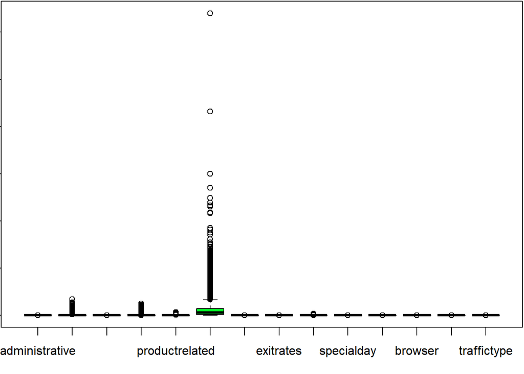

```r
#Visualize the outliers

# Margins area
par(oma=c(3,0,0,0)) # all sides have 3 lines of space
par(mar=c(0,0,0,0) + 0.1)

fig <- boxplot(df, col = rainbow(ncol(df)))
```

```r
# Listing the outliers
OutVals = boxplot(df, plot=FALSE, col = ncol(df))$out
OutVals
```

[output not shown]

[output cut: 4451 more lines]

```r
#Removing outliers from each column

shoppers1 = shoppers
shoppers1<- shoppers[-which(shoppers$administrative %in% OutVals ),]
shoppers1<- shoppers[-which(shoppers$administrative_duration %in% OutVals ),]
shoppers1<- shoppers[-which(shoppers$informational%in% OutVals ),]
shoppers1<- shoppers[-which(shoppers$informational_duration %in% OutVals ),]
shoppers1<- shoppers[-which(shoppers$productrelated %in% OutVals ),]
shoppers1<- shoppers[-which(shoppers$productrelated_duration %in% OutVals),]
```

```r
#check the difference after removing outliers
print(dim(shoppers))
```

```
## [1] 12199    18
```

```r
print(dim(shoppers1))
```

```
## [1] 8956   18
```

## *Perform Exploratory Data Analysis*

## *Univariate Analysis*

```r
# Creating a Subset
df1 <-subset(shoppers1, select = -c(month, visitortype, weekend, revenue))
print("Modified Data Frame")
```

```
## [1] "Modified Data Frame"
```

```r
head(df1)
```

```
## # A tibble: 6 × 14
##   administrative administrative_d… informational informational_d… productrelated
##            <dbl>             <dbl>         <dbl>            <dbl>          <dbl>
## 1              0                 0             0                0              1
## 2              0                 0             0                0              2
## 3              0                 0             0                0             10
## 4              0                 0             0                0             19
## 5              0                 0             0                0             16
## 6              2                53             0                0             23
## # … with 9 more variables: productrelated_duration <dbl>, bouncerates <dbl>,
## #   exitrates <dbl>, pagevalues <dbl>, specialday <dbl>,
## #   operatingsystems <dbl>, browser <dbl>, region <dbl>, traffictype <dbl>
```

```r
#Descriptive statistics for each column

desc_stats <- data.frame(
  Min = apply(df1, 2, min),    # minimum
  Max = apply(df1, 2, max),     # Maximum
  Med = apply(df1, 2, median), # median
  Mean = apply(df1, 2, mean),  # mean
  variance= apply(df1, 2, var),  #Variance
  SD = apply(df1, 2, sd)   # Standard deviation
  )
```

```r
desc_stats <- round(desc_stats, 1)
desc_stats
```

```
##                         Min    Max   Med  Mean variance    SD
## administrative            0   24.0   1.0   2.4     10.1   3.2
## administrative_duration   0 2156.2  18.0  82.4  27089.0 164.6
## informational             0   16.0   0.0   0.5      1.4   1.2
## informational_duration    0 2252.0   0.0  30.4  15301.2 123.7
## productrelated            0  223.0  21.0  27.6    589.3  24.3
## productrelated_duration   0 3401.3 735.9 961.0 663437.4 814.5
## bouncerates               0    0.2   0.0   0.0      0.0   0.0
## exitrates                 0    0.2   0.0   0.0      0.0   0.0
## pagevalues                0  361.8   0.0   6.9    407.4  20.2
## specialday                0    1.0   0.0   0.1      0.0   0.2
## operatingsystems          1    8.0   2.0   2.1      0.9   0.9
## browser                   1   13.0   2.0   2.3      2.9   1.7
## region                    1    9.0   3.0   3.2      5.8   2.4
## traffictype               1   20.0   2.0   4.1     16.1   4.0
```

## *Mode*

```r
#Get the mode

getmode <- function(v) {
   uniqv <- unique(v)
   uniqv[which.max(tabulate(match(v, uniqv)))]
}


attach(shoppers1)
 print("The mode of the administrative column is " )
```

```
## [1] "The mode of the administrative column is "
```

```r
getmode(administrative);
```

```
## [1] 0
```

```r
 print("The mode of the administrative_duration column is " )
```

```
## [1] "The mode of the administrative_duration column is "
```

```r
 getmode(administrative_duration);
```

```
## [1] 0
```

```r
print("The mode of the informational column is " )
```

```
## [1] "The mode of the informational column is "
```

```r
getmode(informational);
```

```
## [1] 0
```

```r
  print("The mode of the informational_duration column is " )
```

```
## [1] "The mode of the informational_duration column is "
```

```r
 getmode(informational_duration);
```

```
## [1] 0
```

```r
print("The mode of the productrelated column is " )
```

```
## [1] "The mode of the productrelated column is "
```

```r
 getmode(productrelated);
```

```
## [1] 1
```

```r
print("The mode of the productrelated_duration column is " )
```

```
## [1] "The mode of the productrelated_duration column is "
```

```r
 getmode(productrelated_duration);
```

```
## [1] 0
```

```r
print("The mode of the bouncerates column is " )
```

```
## [1] "The mode of the bouncerates column is "
```

```r
 getmode(bouncerates);
```

```
## [1] 0
```

```r
 print("The mode of the exitrates column is " )
```

```
## [1] "The mode of the exitrates column is "
```

```r
  getmode(exitrates);
```

```
## [1] 0.2
```

```r
 print("The mode of the pagevalues column is " )
```

```
## [1] "The mode of the pagevalues column is "
```

```r
  getmode(pagevalues)
```

```
## [1] 0
```

```r
   print("The mode of the specialday column is " )
```

```
## [1] "The mode of the specialday column is "
```

```r
  getmode(specialday)
```

```
## [1] 0
```

```r
 print("The mode of the operatingsystems column is " )
```

```
## [1] "The mode of the operatingsystems column is "
```

```r
  getmode(operatingsystems)
```

```
## [1] 2
```

```r
 print("The mode of the browser column is " )
```

```
## [1] "The mode of the browser column is "
```

```r
  getmode(browser)
```

```
## [1] 2
```

```r
 print("The mode of the region column is " )
```

```
## [1] "The mode of the region column is "
```

```r
  getmode(region)
```

```
## [1] 1
```

```r
 print("The mode of the traffictype column is " )
```

```
## [1] "The mode of the traffictype column is "
```

```r
  getmode(traffictype)
```

```
## [1] 2
```

```r
#check the quantiles  values of every column
 Quantiles = apply(df1, 2, quantile)     # Quantile
Quantiles
```

```
##      administrative administrative_duration informational
## 0%                0                   0.000             0
## 25%               0                   0.000             0
## 50%               1                  18.000             0
## 75%               4                 100.150             0
## 100%             24                2156.167            16
##      informational_duration productrelated productrelated_duration bouncerates
## 0%                    0.000              0                  0.0000 0.000000000
## 25%                   0.000             11                318.6958 0.000000000
## 50%                   0.000             21                735.9083 0.003846154
## 75%                   0.000             37               1414.7888 0.016666667
## 100%               2252.033            223               3401.3000 0.200000000
##       exitrates pagevalues specialday operatingsystems browser region
## 0%   0.00000000     0.0000          0                1       1      1
## 25%  0.01250000     0.0000          0                2       2      1
## 50%  0.02307692     0.0000          0                2       2      3
## 75%  0.04060606     0.0000          0                3       2      4
## 100% 0.20000000   361.7637          1                8      13      9
##      traffictype
## 0%             1
## 25%            2
## 50%            2
## 75%            4
## 100%          20
```

```r
#check the range of  values of every column
Range = apply(df1, 2, range)    # Range
Range
```

```
##      administrative administrative_duration informational
## [1,]              0                   0.000             0
## [2,]             24                2156.167            16
##      informational_duration productrelated productrelated_duration bouncerates
## [1,]                  0.000              0                     0.0         0.0
## [2,]               2252.033            223                  3401.3         0.2
##      exitrates pagevalues specialday operatingsystems browser region
## [1,]       0.0     0.0000          0                1       1      1
## [2,]       0.2   361.7637          1                8      13      9
##      traffictype
## [1,]           1
## [2,]          20
```

*Administatrive*

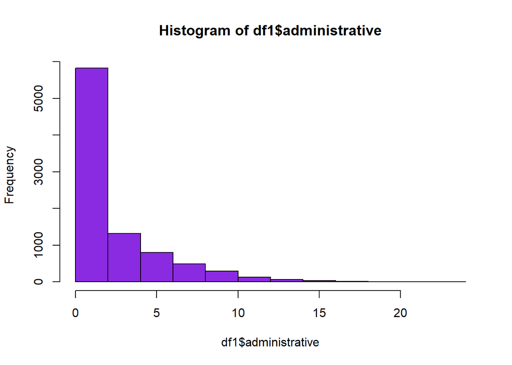

```r
#See the administrative distribution
hist(df1$administrative, col='blueviolet')
```

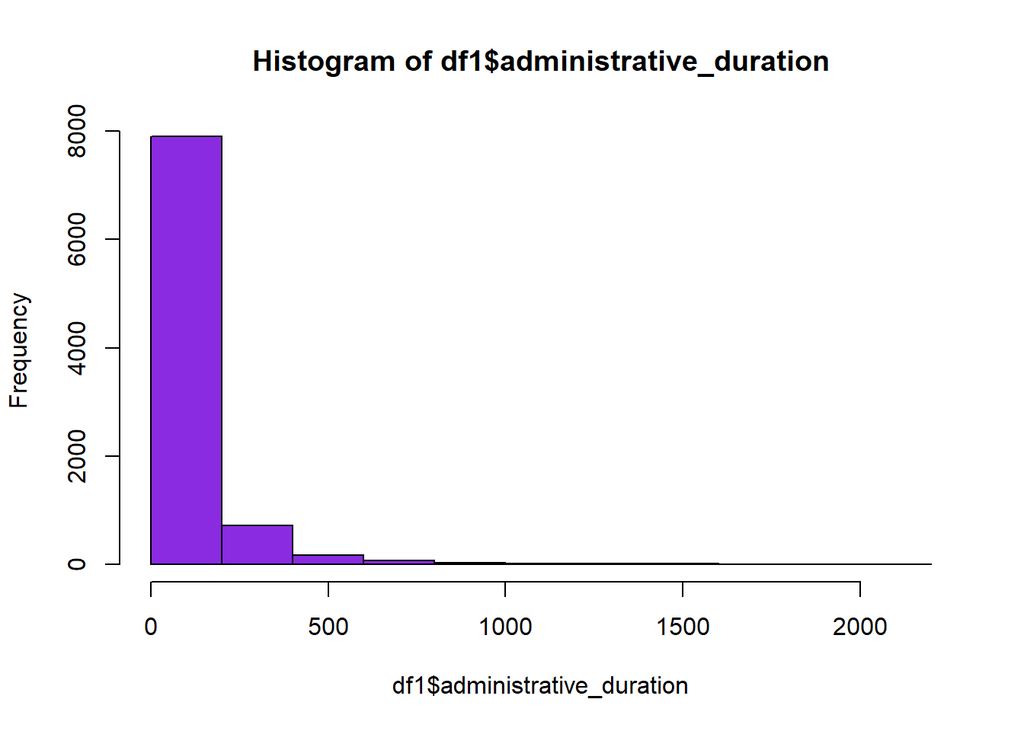

```r
#See the administrative_duration distribution
hist(df1$administrative_duration, col='blueviolet')
```

*Informational*

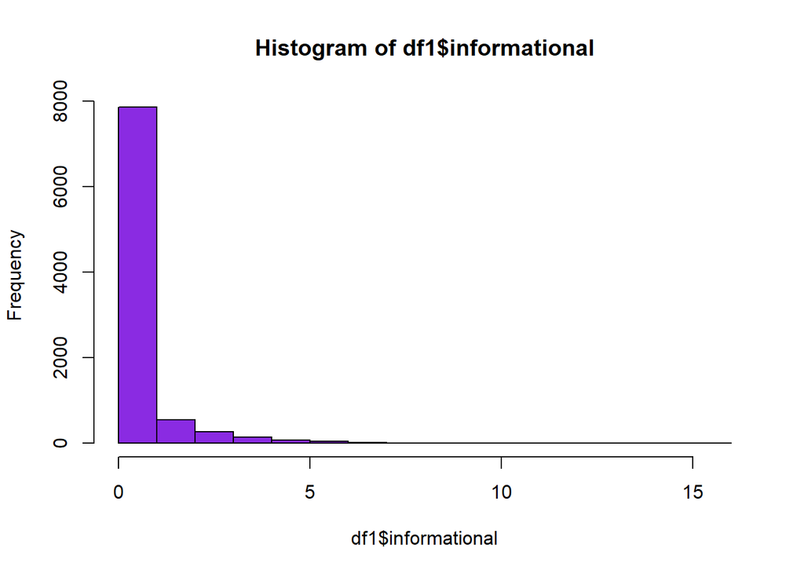

```r
hist(df1$informational, col='blueviolet')  #See the informational distribution
```

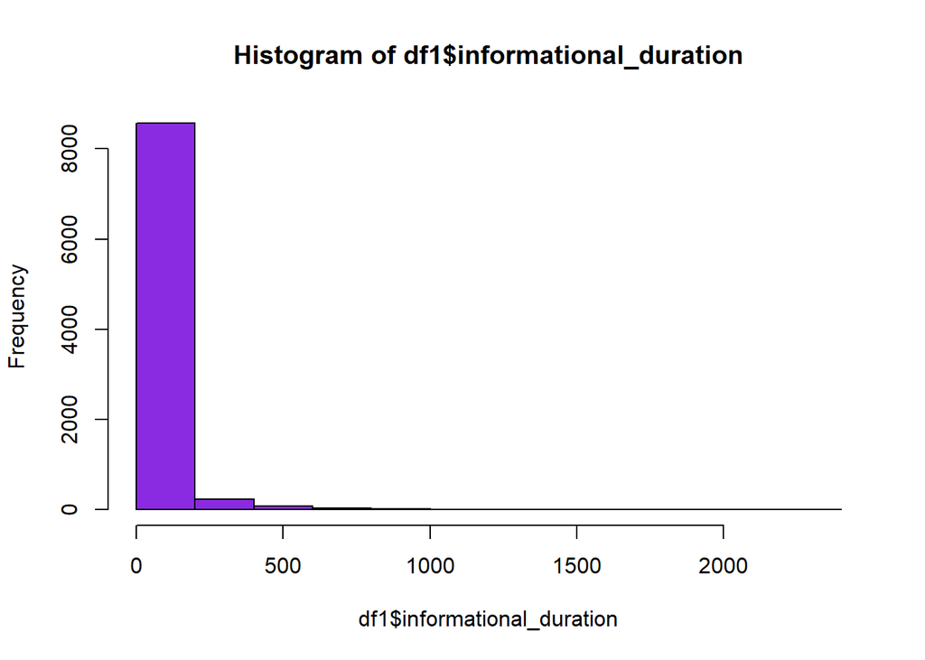

```r
#See the informational_duration distribution
hist(df1$informational_duration, col='blueviolet')
```

*Product related*

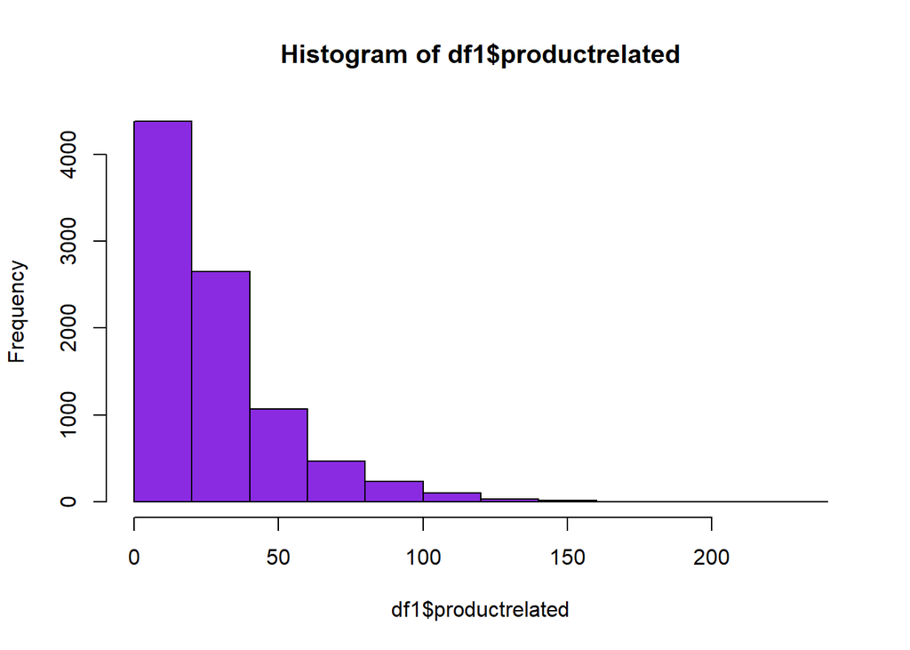

```r
hist(df1$productrelated, col='blueviolet') #See the productrelated distribution
```

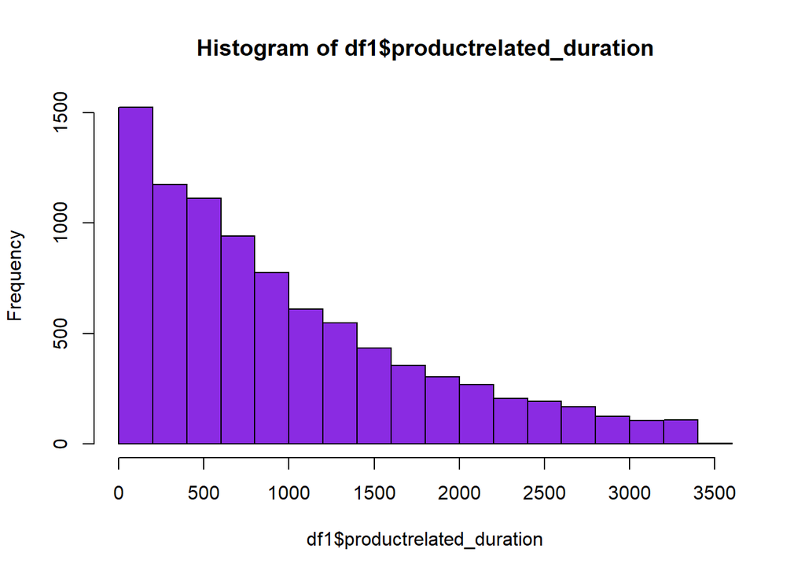

```r
hist(df1$productrelated_duration, col='blueviolet')  #See the productrelated_duration distribution
```

*Bouncerates*

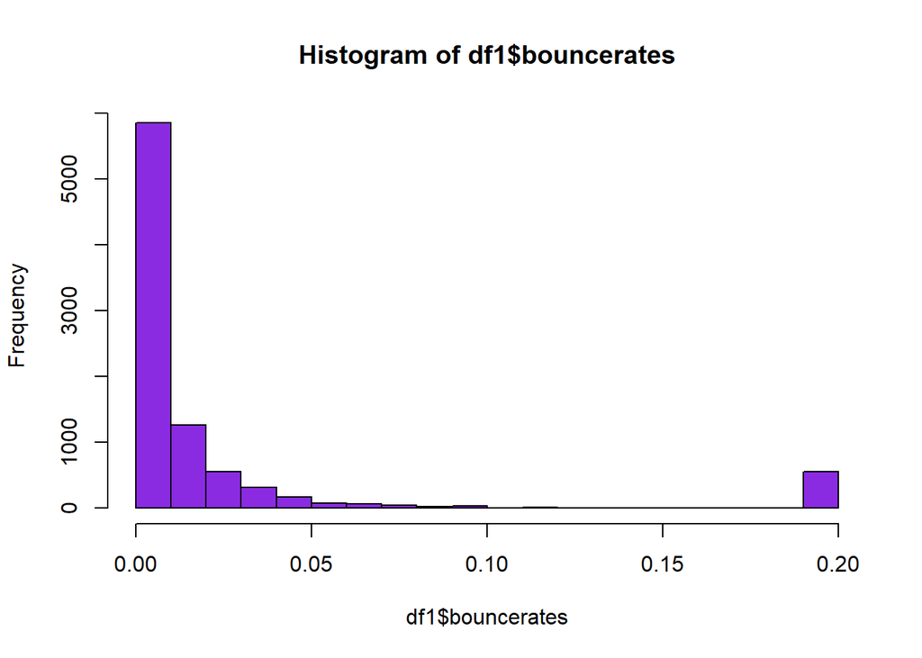

```r
hist(df1$bouncerates, col='blueviolet')
```

*Exitrates*

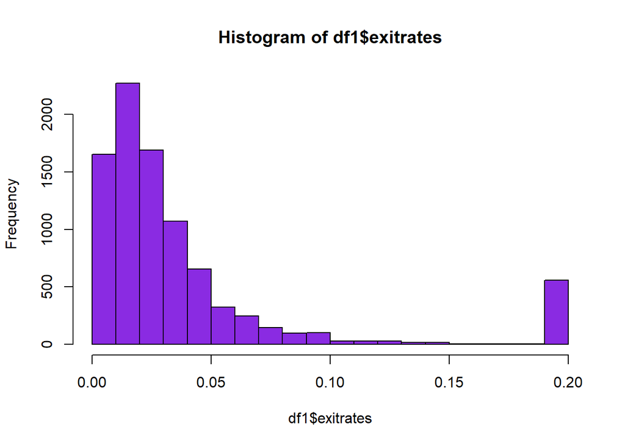

```r
hist(df1$exitrates, col='blueviolet')
```

*page-values*

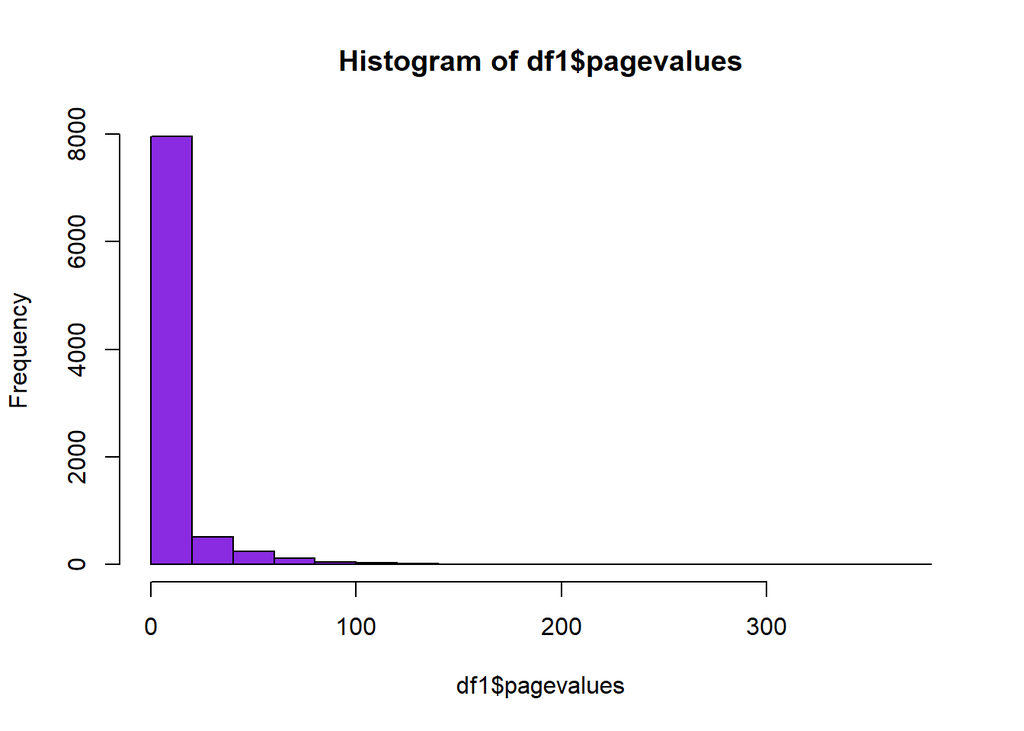

```r
hist(df1$pagevalues, col='blueviolet')
```

*Special day*

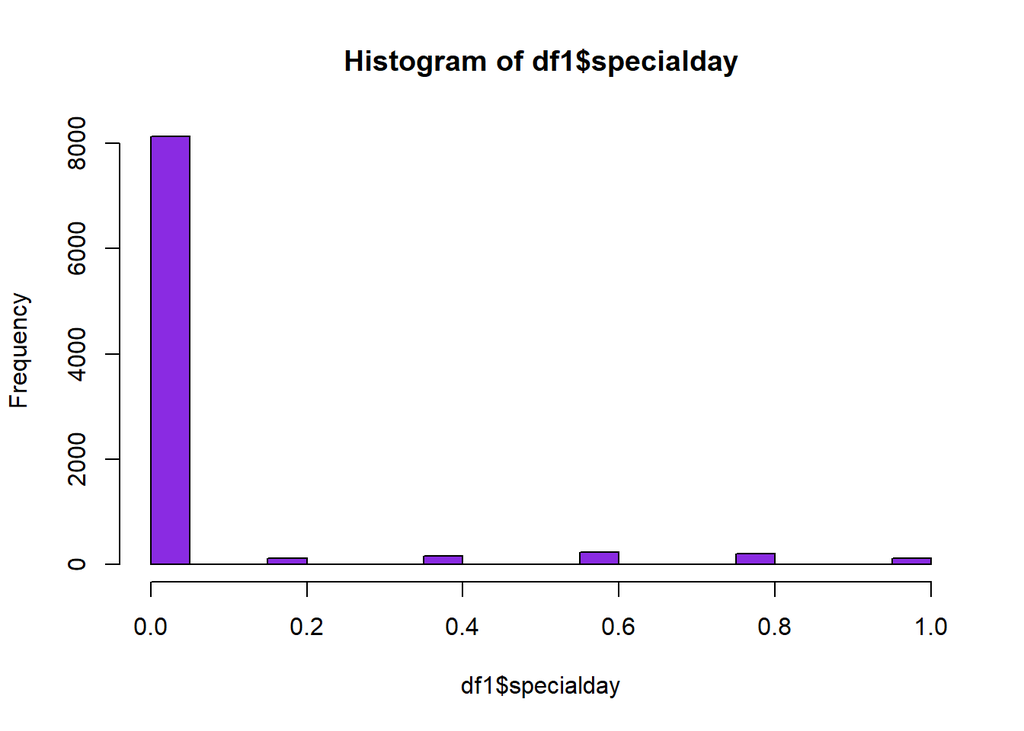

```r
#See the daily_time_spent_on_site distribution
hist(df1$specialday, col='blueviolet')
```

*Computers*

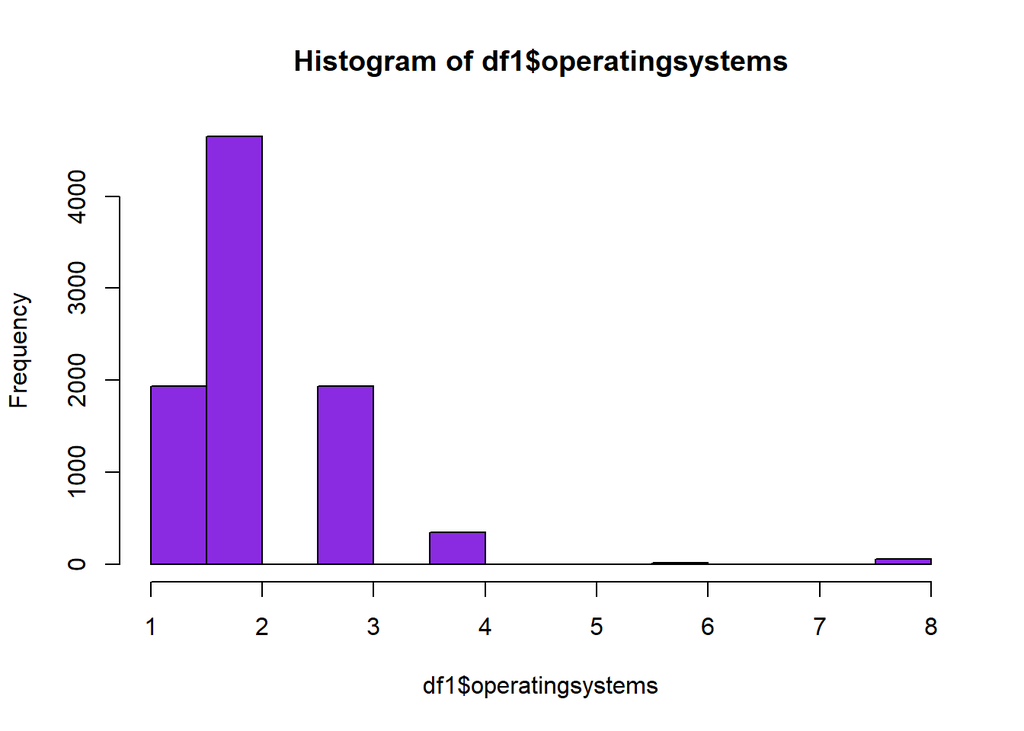

```r
#See the operatingsystems distribution
hist(df1$operatingsystems, col='blueviolet')
```

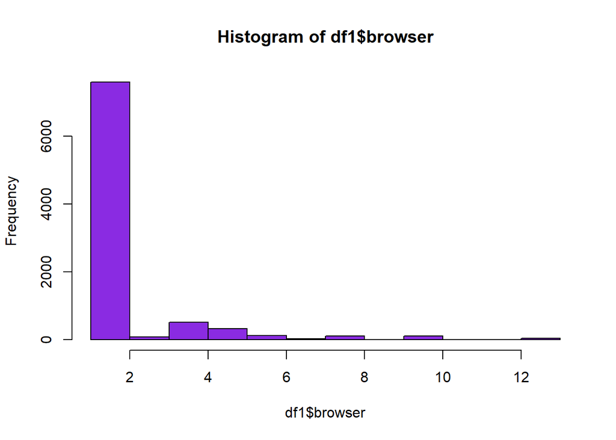

```r
#See the browser distribution
hist(df1$browser, col='blueviolet')
```

*Traffic type*

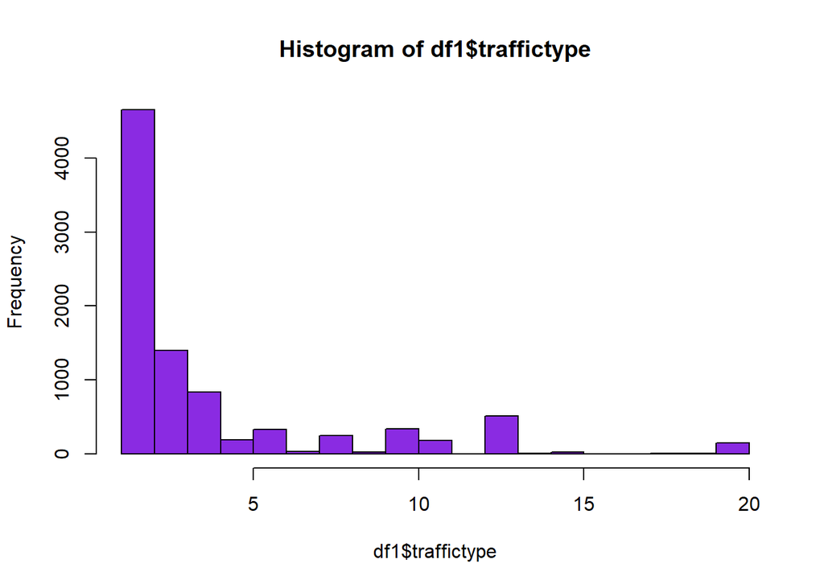

```r
#See the traffictype distribution
hist(df1$traffictype, col='blueviolet')
```

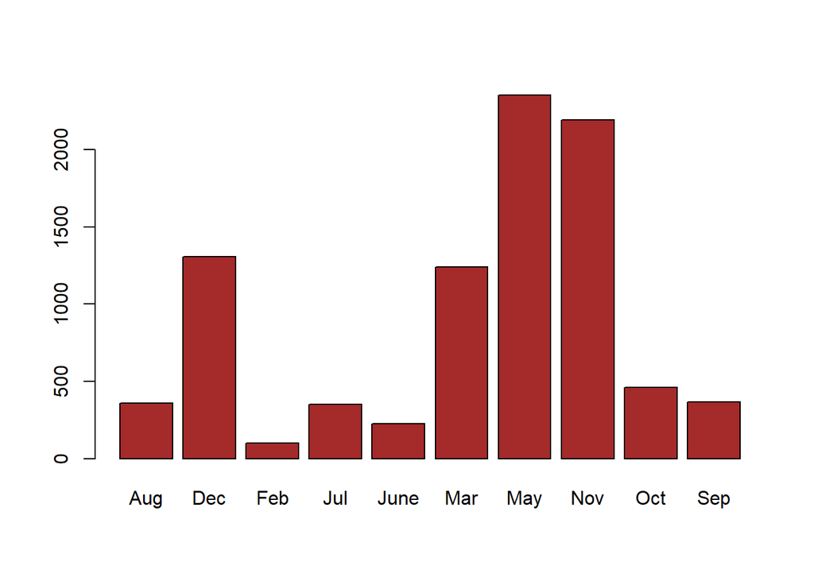

```r
# Getting specific column - month
month1 <-shoppers1$month

# Applying the table() function will compute the frequency distribution of the month variable
# ---
#
month_frequency1 <- table(month1)


# Then applying the barplot function to produce its bar graph
# ---
#
barplot(month_frequency1, col=c("brown"))
```

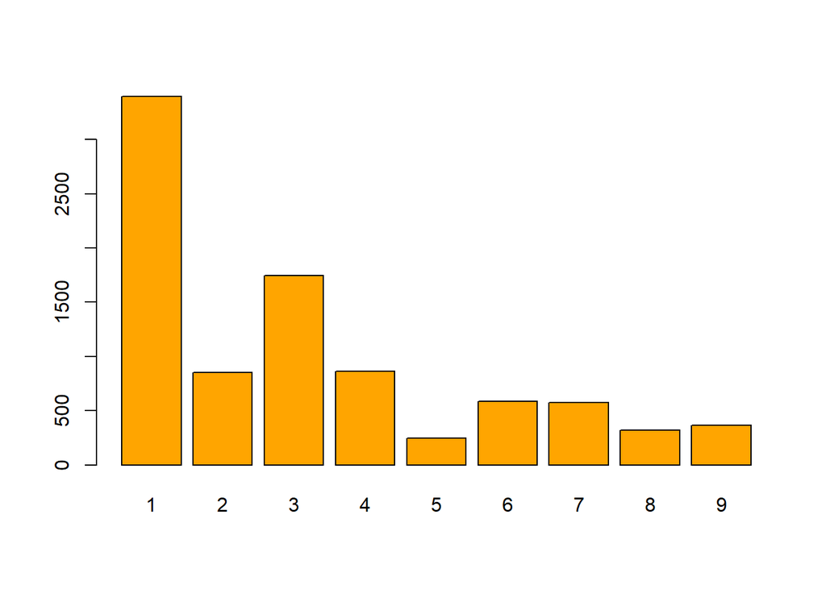

```r
# Getting specific column - region
regions <-shoppers1$region

# Applying the table() function will compute the frequency distribution of the region variable
# ---
#
regions_frequency1 <- table(regions)


# Then applying the barplot function to produce its bar graph
# ---
#
barplot(regions_frequency1, col=c("orange"))
```

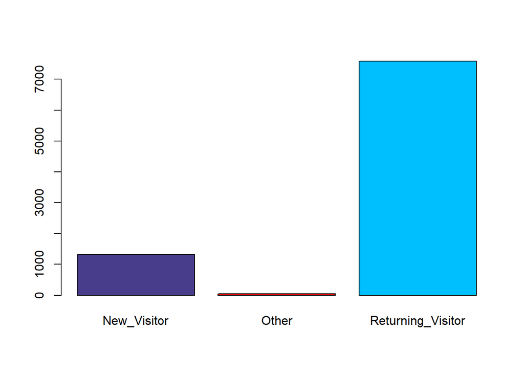

```r
# Getting specific column - visitortype
visitors <-shoppers1$visitortype

# Applying the table() function will compute the frequency distribution of the visitortype variable
# ---
#
visitors_frequency1 <- table(visitors)


# Then applying the barplot function to produce its bar graph
# ---
#
barplot(visitors_frequency1, col=c("darkslateblue", "red", "deepskyblue"))
```

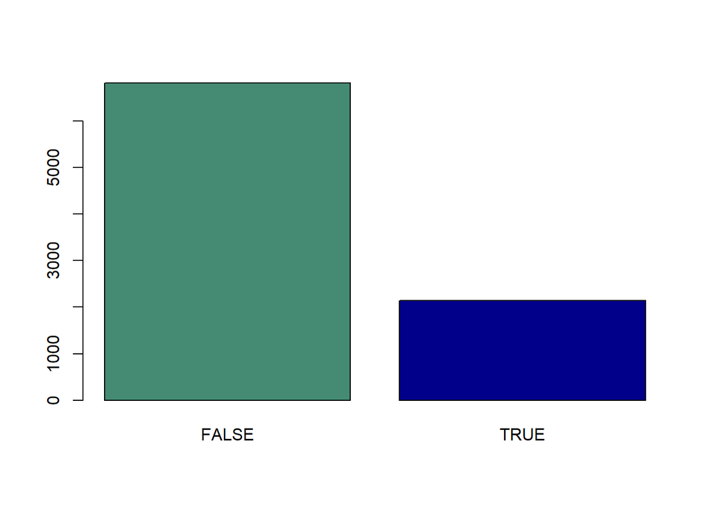

```r
# Getting specific column - weekend
weekends <- shoppers1$weekend

# Applying the table() function will compute the frequency distribution of the weekend variable
# ---
#
weekend_frequency1 <- table(weekends)


# Then applying the barplot function to produce its bar graph
# ---
#
barplot(weekend_frequency1, col=c("aquamarine4", "blue4"))
```

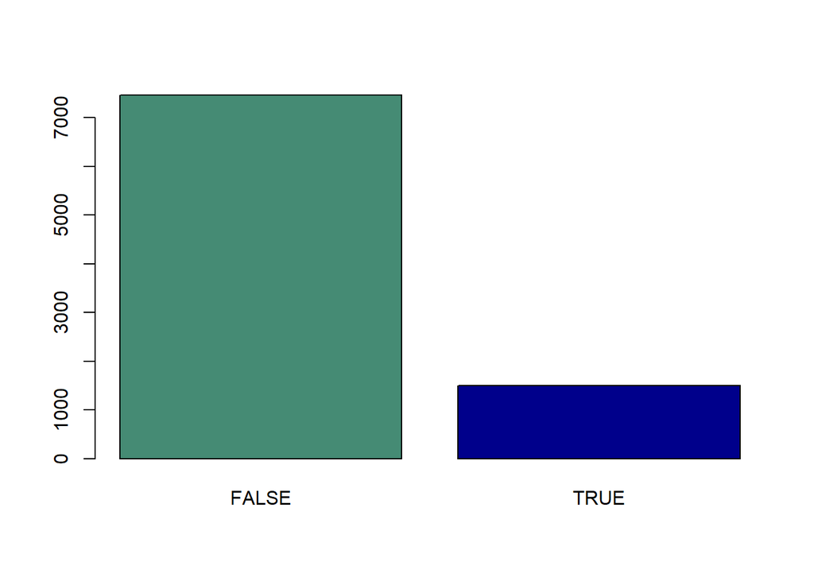

```r
# Getting specific column - revenue
revenues <- shoppers1$revenue

# Applying the table() function will compute the frequency distribution of the revenue variable
# ---
#
revenues_frequency1 <- table(revenues)


# Then applying the barplot function to produce its bar graph
# ---
#
barplot(revenues_frequency1, col=c("aquamarine4", "blue4"))
```

## *Bivariate Analysis*

*Revenue by day type*

```r
library(magrittr)
```

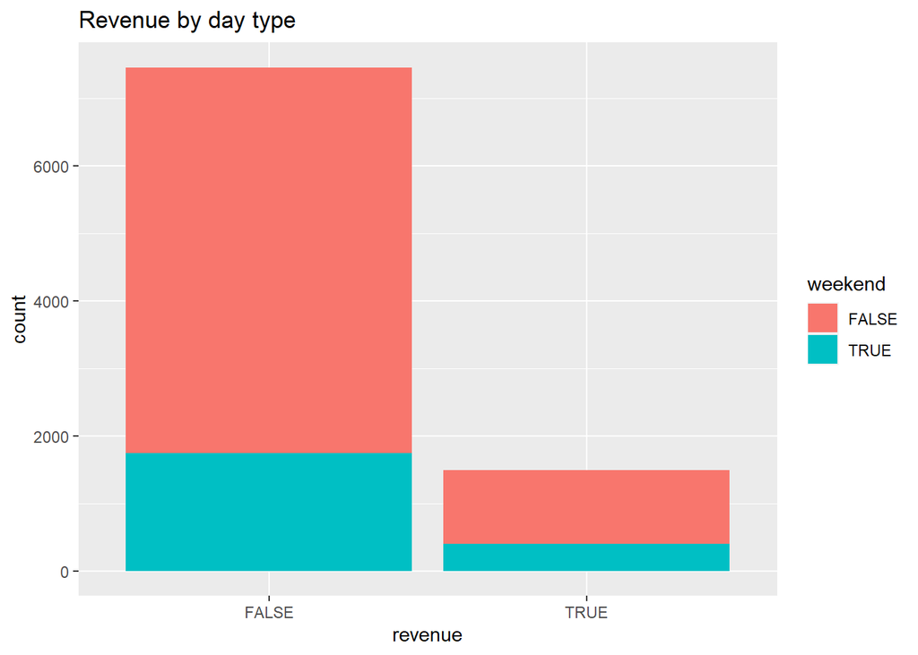

```r
shoppers1 %>%
   ggplot(aes(revenue)) +
   geom_bar(aes(fill= weekend))+
   labs(title = "Revenue by day type")
```

*Revenue by month*

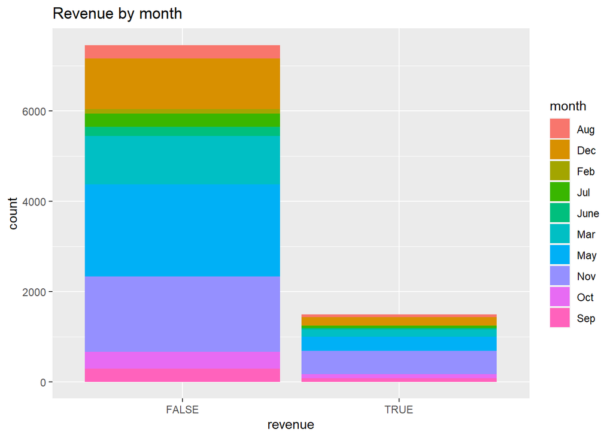

```r
library(magrittr)
shoppers1 %>%
   ggplot(aes(revenue)) +
   geom_bar(aes(fill= month))+
   labs(title = "Revenue by month")
```

*Revenue by visitor type*

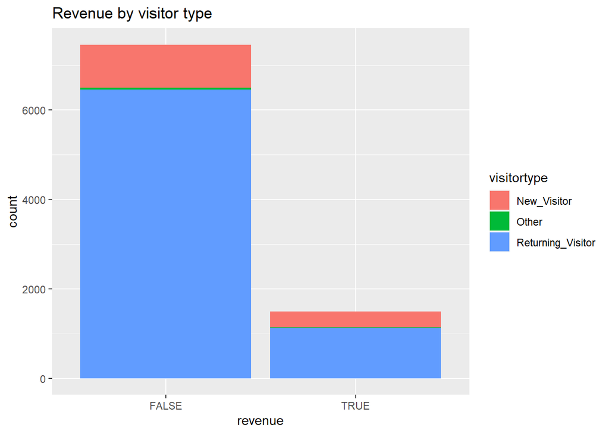

```r
library(magrittr)
shoppers1 %>%
   ggplot(aes(revenue)) +
   geom_bar(aes(fill= visitortype))+
   labs(title = "Revenue by visitor type")
```

*Time spent on Informational_ duration versus administrative_duration*

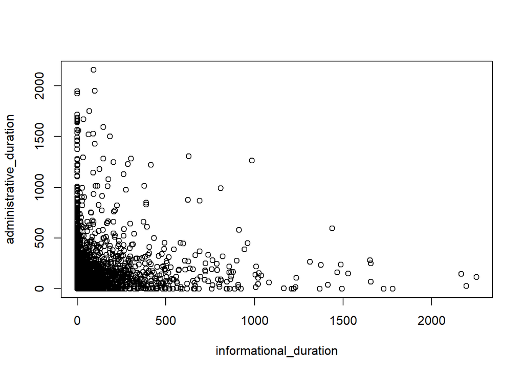

```r
plot(informational_duration,administrative_duration,  xlab="informational_duration", ylab="administrative_duration") # Drawwing a scatterplot
```

```r
cor(informational_duration,administrative_duration) #Correlation Coefficient
```

```
## [1] 0.1332411
```

```r
cov(informational_duration,administrative_duration)
```

```
## [1] 2712.677
```

*Bouncerates versus exit rates*

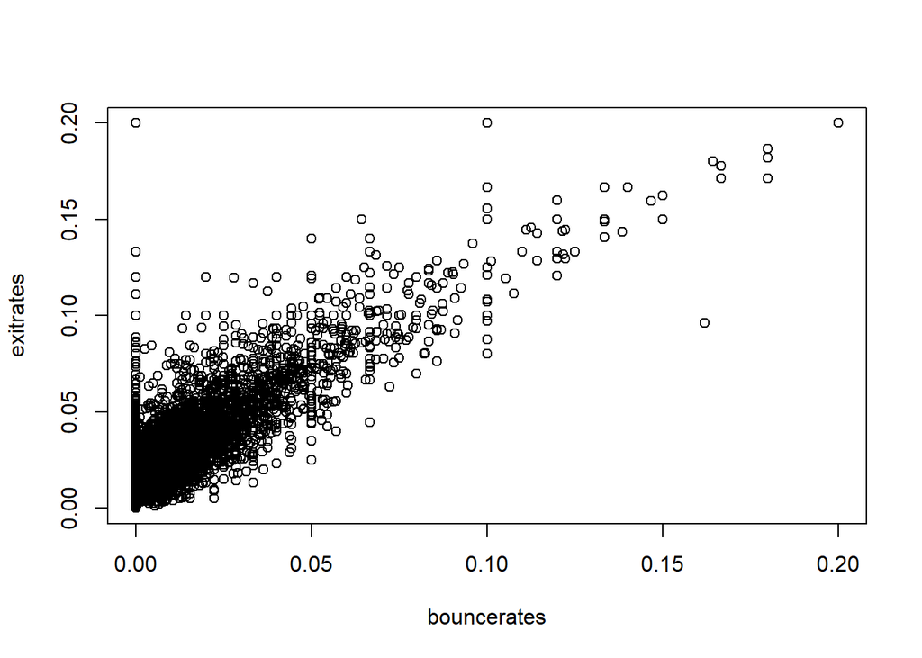

```r
plot(bouncerates,exitrates,  xlab="bouncerates", ylab="exitrates") # Drawwing a scatterplot
```

```r
cor(bouncerates,exitrates) #Correlation Coefficient
```

```
## [1] 0.9479605
```

```r
cov(bouncerates,exitrates)
```

```
## [1] 0.002185605
```

## *Multivariate Analysis*

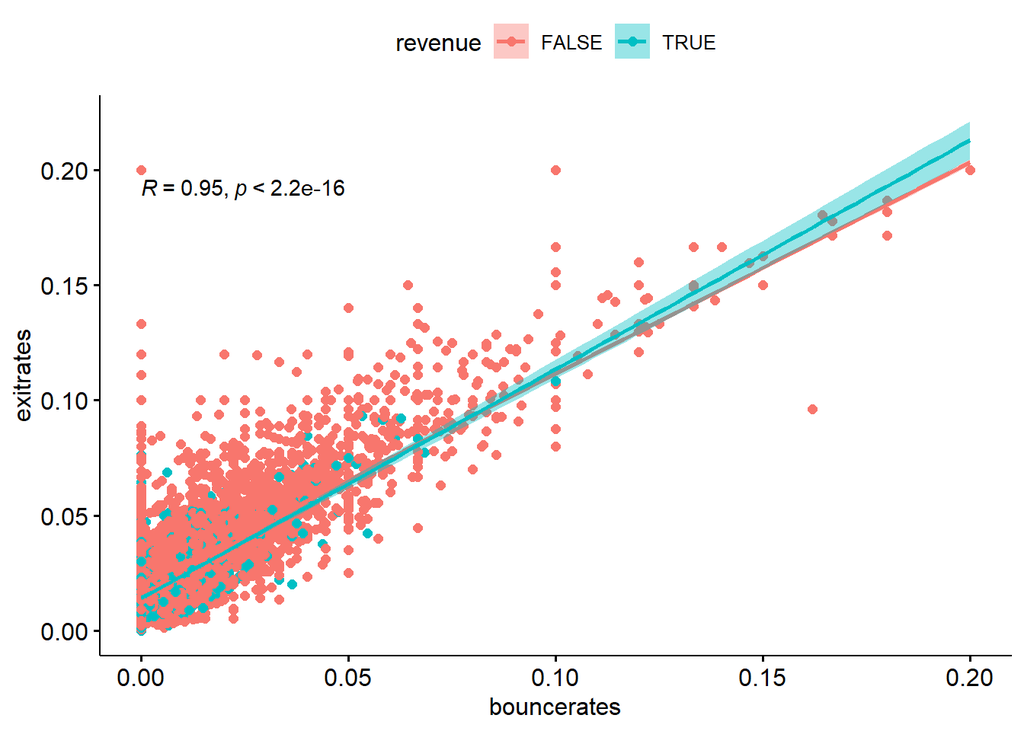

```r
library("ggpubr")
ggscatter(shoppers1, x = "bouncerates", y = "exitrates",
          add = "reg.line", conf.int = TRUE,
          cor.coef = TRUE, cor.method = "pearson",
          xlab = "bouncerates", ylab = "exitrates",  color = "revenue")
```

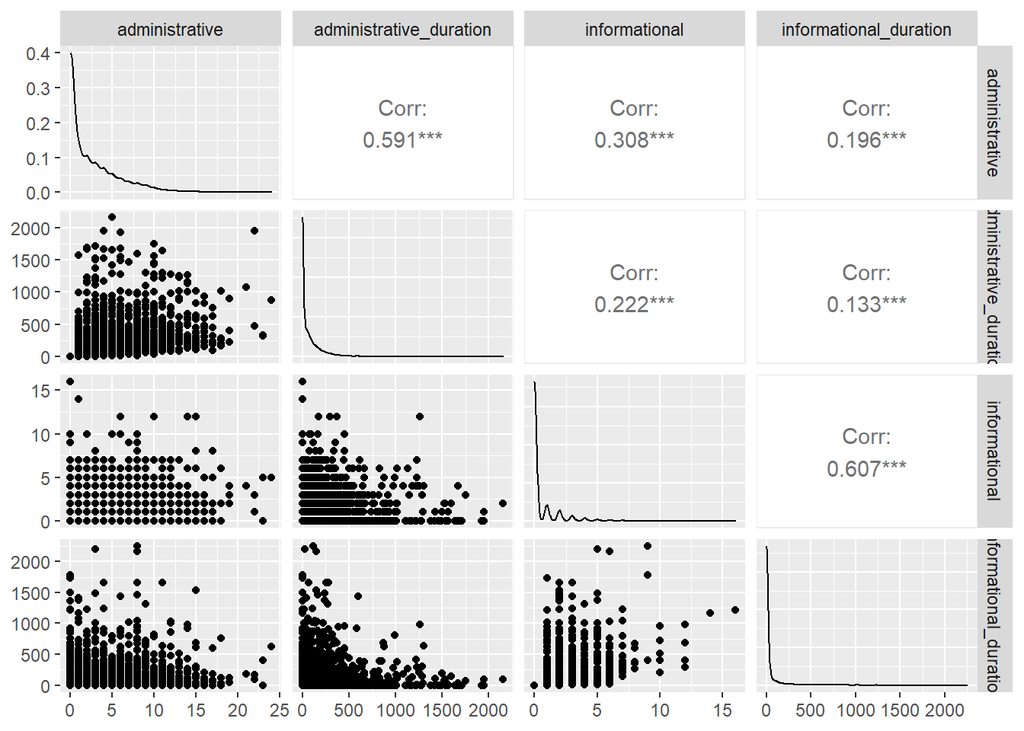

```r
ggpairs(shoppers1[1:4])
```

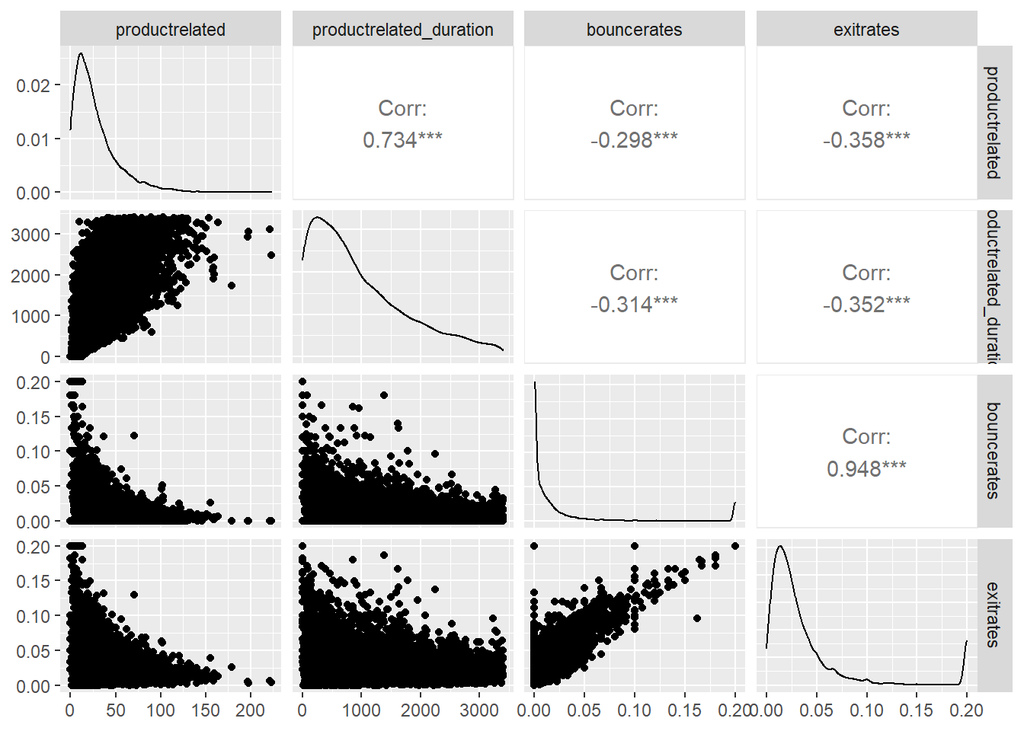

```r
ggpairs(shoppers1[5:8])
```

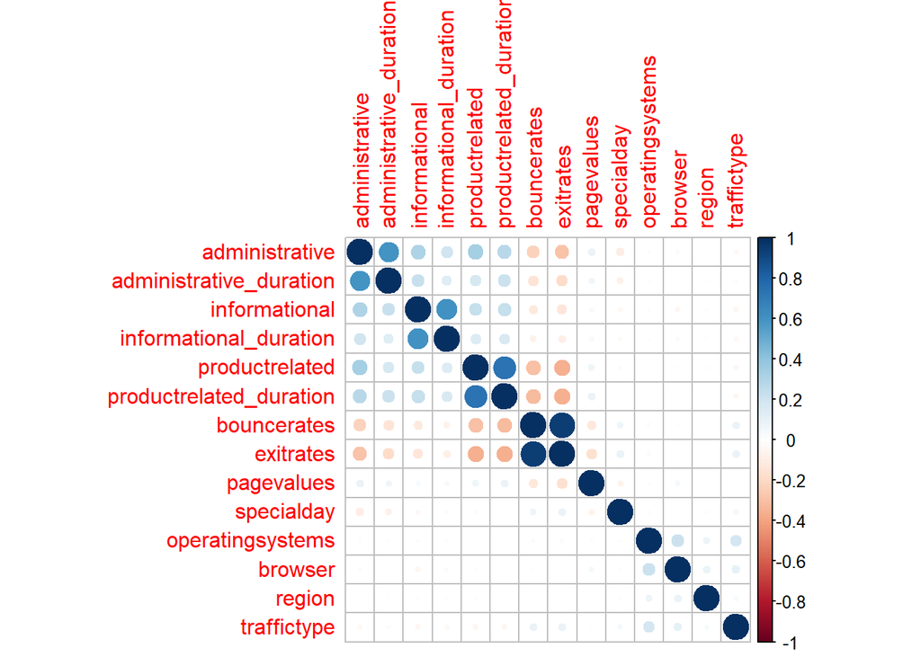

```r
M<-cor(df1) #find the correlation
library(corrplot)
# Margins area
par(oma=c(0,0,0,0)) # all sides have 3 lines of space
par(mar=c(0,0,0,0) + 0.1)
corrplot(M, method="circle") #Compute and visualize the correlation co-eeficients
```